# An Exploration of Network Analysis Through Macbeth

Julis Koch

31/12/2021

## INTRODUCTION

Whilst perhaps karmic or malicious in nature, and tragic in consequence, social network analysis may help provide a more social structural analysis of death. More specifically, it suggest that evil may be the result of social interaction and plot, as I am going to show in the following.

## DATASET AND LIMITATIONS

The dataset of Shakespeare’s Macbeth was extracted from https://github.com/mallaham/Shakespeare-Plays. I did not verify completion or factual accuracy, which is why the number of characters may vary from the original play. Due to time constraints and feasibility, the network presented is unidirectional, defined by co-appearance and first speaker. Accordingly, response and further interaction is not captured appropriately. Moreover, while I initially accounted for attributes such as gender, cause.of.death and power, these did not translate into the network simulations as desired. I have hence broadened the scope of inquiry. This piece can thus be considered an explorational network analysis of what not to research, confirming ‘social fundamentals’ and pointing out future aspects of network analysis of Shakespeare’s plays instead. Finally, the ERGM model only partially converted - with the Markov calculation excluded from the code.

## HYPOTHESIS

H1 Interactions in Macbeth are random, such that intrigues and murder cannot be inferred.

H2 Malicious behaviour may be characterised by unidirectional interaction, as is expressed, for instance, in a comparatively low probability coefficient when observing a tie in a diad.

H3 Regardless, the clustering of individuals reflects findings of established eigenvector nodes.

## RANDOMNESS OF TIES IN SHAKESPEARE’S MACBETH (H1)

```
## # A tibble: 188 x 2
##    from      to
##    <chr>     <chr>
##  1 angus     caithness
##  2 angus     lennox
##  3 attendant both murderers
##  4 attendant first murderer
##  5 attendant second murderer
##  6 banquo    angus
##  7 banquo    attendant
##  8 banquo    both murderers
##  9 banquo    donalbain
## 10 banquo    first murderer
## # ... with 178 more rows
```

```
##  Network attributes:
##   vertices = 40
##   directed = TRUE
##   hyper = FALSE
##   loops = FALSE
##   multiple = FALSE
##   bipartite = FALSE
##   total edges= 188
##     missing edges= 0
##     non-missing edges= 188
##
##  Vertex attribute names:
##     vertex.names
##
## No edge attributes
```

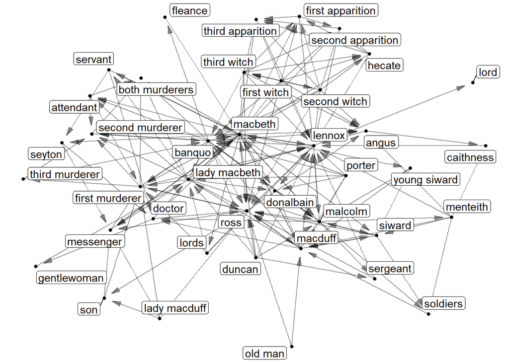

```
## Call:
## ergm(formula = macbeth.s ~ edges)
##
## Maximum Likelihood Results:
##
##       Estimate Std. Error MCMC % z value Pr(>|z|)
## edges -1.98758    0.07777      0  -25.56   <1e-04 ***
## ---
## Signif. codes:  0 '***' 0.001 '**' 0.01 '*' 0.05 '.' 0.1 ' ' 1
##
##      Null Deviance: 2163  on 1560  degrees of freedom
##  Residual Deviance: 1148  on 1559  degrees of freedom
##
## AIC: 1150  BIC: 1155  (Smaller is better. MC Std. Err. = 0)
```

```
##     edges
## -1.987583
```

```
##     edges
## 0.1205128
```

The p-value of < 0.001 indicates strong significance for the ties to not occur at random; the specific value of AIC and BIC would need to be further explored in additional models to establish model fit at this stage.

The corresponding probability of a tie change is -1.987583; with the probability of a tie in a dIad being fairly low, namely at 0.1205128. This statistic would also allow for a conclusion on the density of the network, but I aNd discussing this aspect later on.

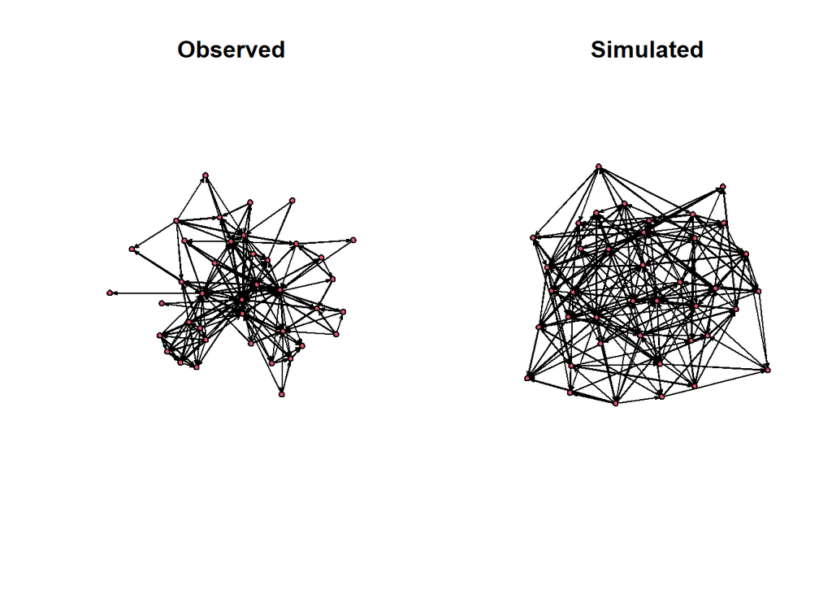

```
## Number of Networks: 100
## Model: macbeth.s ~ edges
## Reference: ~Bernoulli
## Constraints: ~.
```

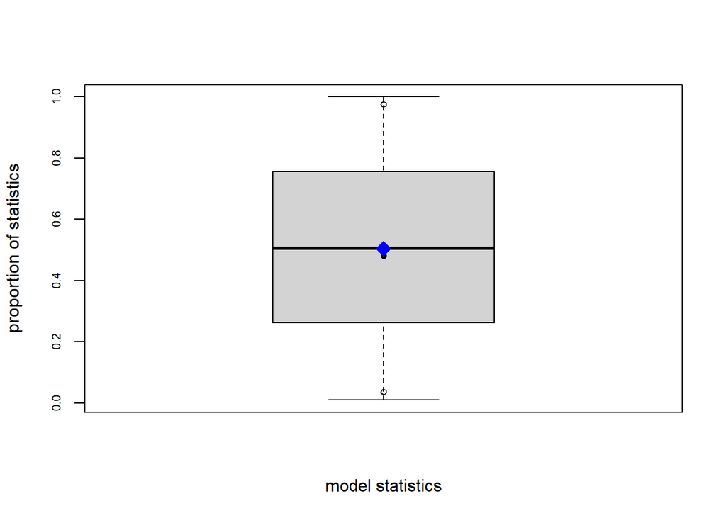

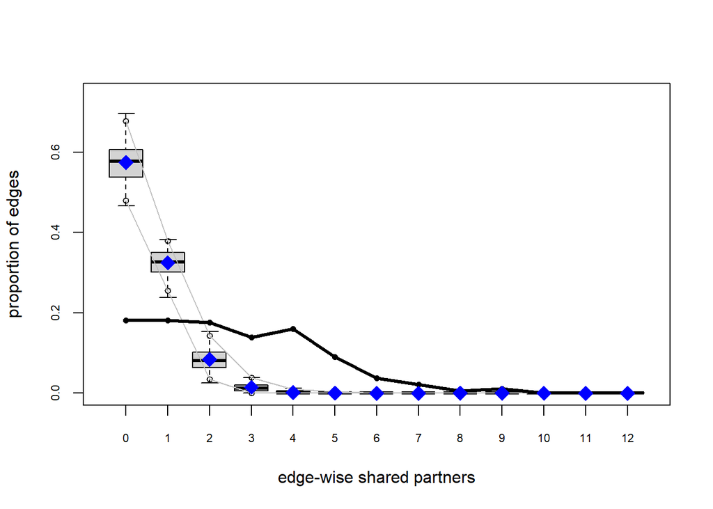

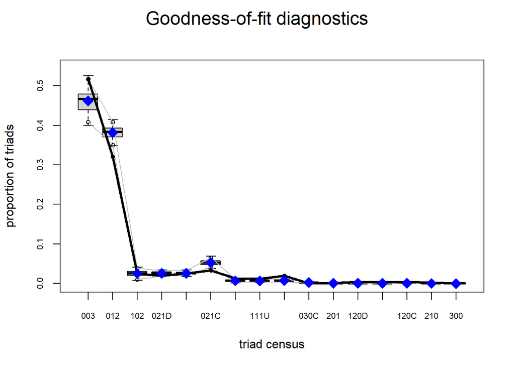

The simulation of edge-wise shared partners is not as accurate, with an inital over-estimation from edge-wise shared partners 0-1, and an underestimation until edgewise-shared partners 8; from 10 we observe absolute fit.

The goodness of fit for triad census is even more accurate mostly convering from 102 onwards, with only a brief overestimation between 021U and 111D.

H1 is disproven overall, implying relevance of also the following findings.

## MALICIOUS BEHAVIOUR AND DYADIC TIES

```
## [1] 0.1205128
```

```
## [1] 0.1914894
```

```
## [1] 0.1058824
```

With 0.12 the network density can be considered scarce; this is also reflected in the the fairly low number of unidirectional (0.19) and reciprocal dyadic interactions (0.11) between characters.

It suggests little collaboration and fairly instantaneous interaction across the course of the play.

```
## [1] 0.4945706
```

While the Markov ERGM Model did not converge, and I could therefore not test for triadic interaction, the network represents a fairly high coefficient for transitivity, suggesting a somewhat high number connected of characters in the form of ‘via-via-acquaintances’ regardless.

## STRONG COMPONENTS OR CLUSTERS OF POWER?

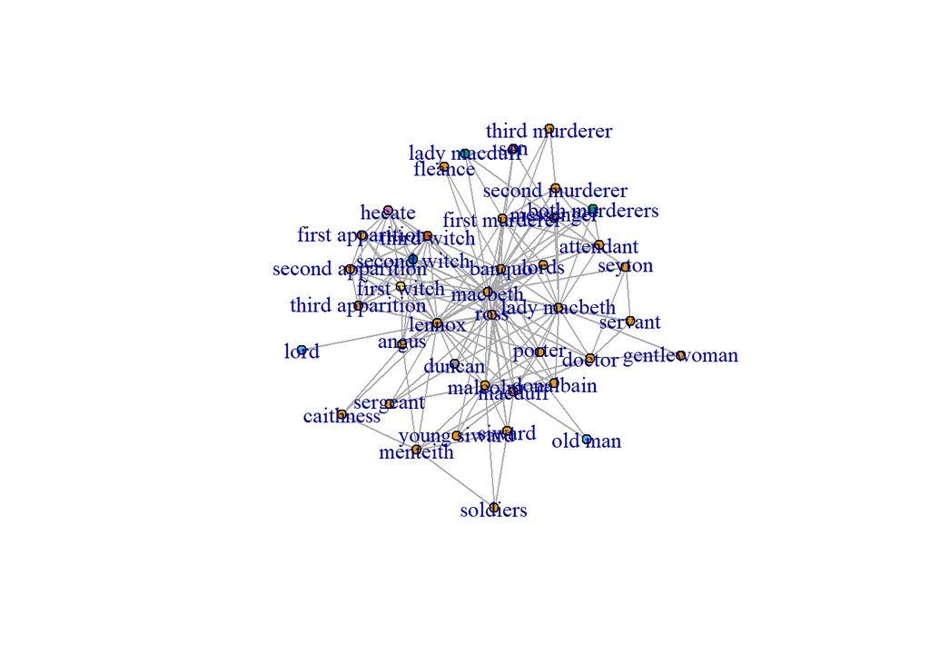

Interestingly, this network is comprised of a surprisingly high number of strong components or individuals (orange), with only a few characters (colourful) being less well connected and fairly removed. The latter represent the weak components of the network.

It may thus be difficult to single out nodes of influence and intrigue among this high number of strong components.

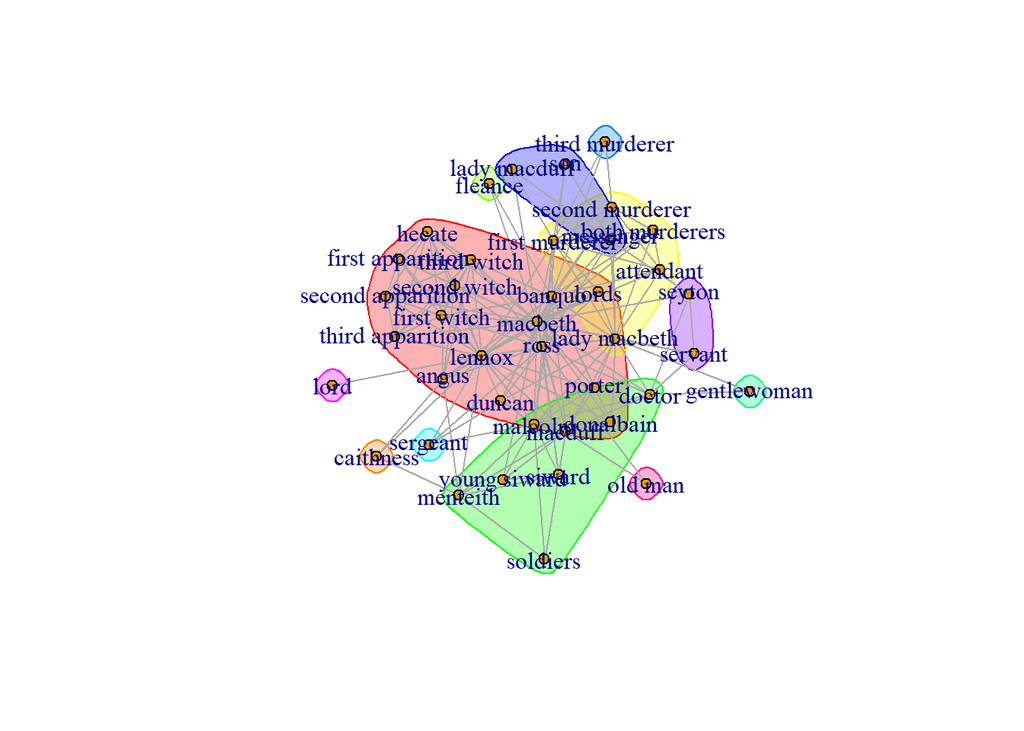

These findings suggest that many of the most powerful people are within proximity, and closely connected.

## CONCLUSION

I have been able to show that in this scarce network of Macbeth characters, no tie is coincidental (H1). Regardless, however, much of the interaction between characters is unidirectional, transitive, but not necessarily dyadic (H2). It may suggest less coordinated intrigue and subsequent action, which surround scenes of murder, or constitute ‘evil’(H2).

What has become evident, is that the powerful are closely clustered (H3).

## FUTURE RESEARCH

As mentioned above, additional attributes may contribute to a more nuanced and insightful study of what contributes to ‘the evil and malicious’ in Shakespeare’s Macbeth, socially speaking.

Moreover, panel data and longitudinal network analysis may demonstrate the evolution of characters’ relationships across various acts.

Regardless, from what we have been able to observe thus far, dis-organised, and loosely tied groups may be considered the norm for lethal intrigues in Macbeth; even if the most powerful are within each others’ proximity.

## WORD COUNT (text only)

917

## REFERENCES

Desmond, W. (2002). Sticky Evil: Macbeth and the Karma of the Equivocal. In God, Literature and Process Thought. Routledge.

Islam, M. S. (2012). Nature of Evil in Macbeth. Arts Faculty Journal, 4, 185â“194. https://doi.org/10.3329/afj.v4i0.12940

Shanley, J. L. (1961). Macbeth: The Tragedy of Evil. College English, 22(5), 305â“311. https://doi.org/10.2307/373470